# Non-identical Bernoulli Trials

The probabilities change, and the mean still settles

Exploring some more distributions, I looked at Bernoulli trials that do not all have the same success probability. The trials are still independent. For a sample of size $n$, as long as $n$ is at least 2, the probability starts at 0.90 on the first observation and decreases evenly to 0.50 on the last. The usual Central Limit Theorem assumes the observations are identically distributed, and that is the assumption I am dropping here. I wanted the smallest $n$ where the sampling distribution of the mean is still approximately normal, and I wanted to know whether 30 is enough.

## The population

There is no single success probability for this population. Observation $t$ succeeds with probability $p_t$. For a sample of size $n$, I set those probabilities in a straight line from 0.90 down to 0.50:

```r
n_show <- 10
observation <- 1:n_show
p_show <- seq(from = 0.90, to = 0.50, length.out = n_show)
data.frame(observation = observation, probability = round(p_show, 3))
```

```
   observation probability
1            1       0.900
2            2       0.856
3            3       0.811
4            4       0.767
5            5       0.722
6            6       0.678
7            7       0.633
8            8       0.589
9            9       0.544
10          10       0.500
```

The first probability is 0.90 and the last is 0.50. The average of a line from 0.90 to 0.50 is $(0.90 + 0.50)/2 = 0.70$, at every sample size in this file. That does not mean every observation has probability 0.70. The theoretical mean of the sample mean is 0.70. The plot below is that schedule for sample size 10. It is the success probabilities, not a sampling distribution.

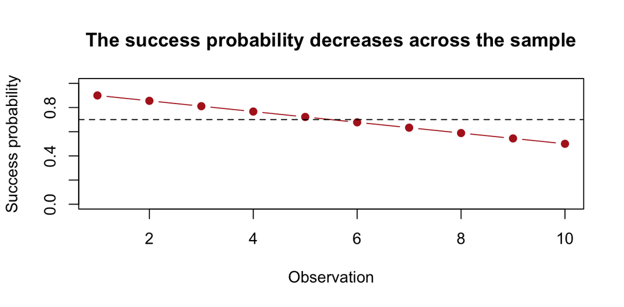

Success probabilities for a sample of size 10. They decrease evenly from 0.90 to 0.50. This is the probability schedule, not a sampling distribution.

One observation cannot run from 0.90 to 0.50, so this file starts at sample size 2. At that size the two probabilities are 0.90 and 0.50.

Each observation is still 0 or 1. The histogram below is 10,000 of those single outcomes, using the sample-size-10 schedule over and over. These are individual observations, not sample means. About 70% of them are successes, because that is the average of the schedule. Averaging later is what pulls the sample mean toward 0.70. A single observation stays 0 or 1.

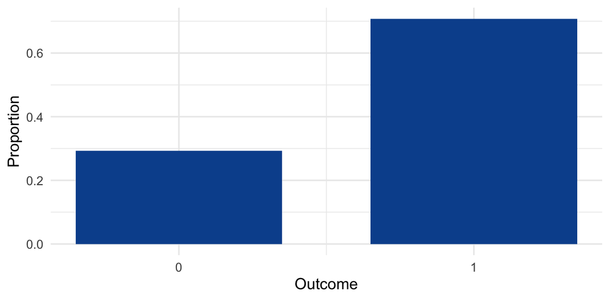

Ten thousand individual Bernoulli outcomes from the sample-size-10 schedule. This is the observations, not a sampling distribution.

It is easy to mix up the population, one sample, and the sampling distribution. The population here is the list of success probabilities, which is what the pictures above show. A sample is one batch of 0s and 1s drawn from that list, and the sampling distribution is the collection of averages I get only after I repeat that sample many times. The Central Limit Theorem is about that last distribution. A single observation stays 0 or 1.

Below I printed one sample of five outcomes, and then their average. That average is one number from one sample. The sampling distribution is the pile of averages I get later, when I repeat the sample 10,000 times.

```r
set.seed(student_id)
one_probabilities <- seq(from = 0.90, to = 0.50, length.out = 5)
made <- rbinom(n = 5, size = 1, prob = one_probabilities)
data.frame(observation = 1:5, probability = round(one_probabilities, 3), made = made)
```

```
  observation probability made
1           1         0.9    1
2           2         0.8    1
3           3         0.7    1
4           4         0.6    1
5           5         0.5    0
```

```r
mean(made)
```

```
[1] 0.8
```

The observations are independent, and each has a finite variance, $p_i(1-p_i)$. They are not identically distributed, so there is no single population standard deviation to put into $\sigma/\sqrt{n}$. The variance of the sample mean adds up the separate variances:

$$\operatorname{Var}(\bar X) = \frac{\sum_{i=1}^{n} p_i(1-p_i)}{n^2}$$

The theoretical standard error is the square root of the sum of $p_t(1-p_t)$, divided by $n$. The skewness of the sample mean is the sum of $p_t(1-p_t)(1-2p_t)$, divided by the sum of $p_t(1-p_t)$ raised to the power 1.5. Most of these probabilities are above 0.5, so that skewness is negative. The formula first drops under 0.25 in absolute value at sample size 10. At sample size 9 it is still just over that line.

## What I expected

Before looking at the simulation, the prediction was:

- The simulated mean should stay on 0.70, and the standard-error ratio should sit near 1 even at a small sample size, if the standard error is built from each observation’s own variance.
- The skewness formula should drop under 0.25 in absolute value at sample size 10. Sample size 9 should fail that formula.
- A simulated skewness under 0.25 should not count when the formula is still over 0.25. One noisy run can dip under the line.
- Near 10 the formula is only barely under 0.25, and a skewness estimate from 10,000 means wobbles by about 0.025. The first Yes may not be a size that stays Yes.
- The histogram should stay a row of separate bars. The possible means are multiples of $1/n$.
- Sample size 30 should pass if independence and finite variance are enough. The identical-distribution assumption is the one this file gives up. I checked the integers around 10 instead of stopping at the first Yes.

Sample sizes 6 and 7 are not the place to look. At those sizes the formula is still well over 0.25, in the same way it is at sample size 5. The change to investigate is between 8 and 18.

## How the experiment was run

The sample size, $n$, is how many Bernoulli observations are averaged to make one sample mean. The number of repetitions, $B = 10000$, is how many of those means were saved. The sample size is never 10,000.

The sample sizes are 2, 3, 4, 5, then every integer from 8 through 18, then 20, 30, 40, 50, 60, 70, 80, and 100. Sample sizes 2 through 5 show the discrete end. The integers from 8 through 18 are the search around the predicted change. Jumping from 10 to 20 would hide a failure in between, and it would make 20 look like the answer only because nothing in between had been tried. Sample size 30 is also the rule of thumb this project is testing.

A sample size counts as normal enough when four things are all true: the absolute skewness of the 10,000 sample means is under 0.25, the theoretical skewness is also under 0.25, the absolute excess kurtosis is under 0.50, and the simulated standard error is within 10% of the theoretical standard error. The theoretical standard error uses the sum of the individual variances. The theoretical skewness is included because this process lands close to the cutoff.

The random seed is the last four digits of the student ID, set once, immediately before the draws.

```r
student_id <- 1069
B <- 10000
sample_sizes <- c(
  2, 3, 4, 5,
  8, 9, 10, 11, 12, 13, 14, 15, 16, 17, 18,
  20, 30, 40, 50, 60, 70, 80, 100
)

skewness <- function(x) {
  z <- (x - mean(x)) / sd(x)
  mean(z^3)
}

excess_kurtosis <- function(x) {
  z <- (x - mean(x)) / sd(x)
  mean(z^4) - 3
}

qq_scaled_rmse <- function(x) {
  x <- sort(x)
  theo <- qnorm(ppoints(length(x)))
  qs <- as.numeric(quantile(x, c(0.25, 0.75)))
  tqs <- qnorm(c(0.25, 0.75))
  slope <- diff(qs) / diff(tqs)
  intercept <- qs[1] - slope * tqs[1]
  fitted <- intercept + slope * theo
  sqrt(mean((x - fitted)^2)) / sd(x)
}

set.seed(student_id)

results <- data.frame()
stored_means <- list()

for (n in sample_sizes) {
  p <- seq(from = 0.90, to = 0.50, length.out = n)
  sample_means <- replicate(B, mean(rbinom(n = n, size = 1, prob = p)))

  variance_sum <- sum(p * (1 - p))
  theoretical_se <- sqrt(variance_sum) / n
  simulated_se <- sd(sample_means)
  theory_skewness <- sum(p * (1 - p) * (1 - 2 * p)) / variance_sum^(3 / 2)

  results <- rbind(
    results,
    data.frame(
      sample_size = n,
      simulated_mean = mean(sample_means),
      theoretical_mean = mean(p),
      simulated_se = simulated_se,
      theoretical_se = theoretical_se,
      se_ratio = simulated_se / theoretical_se,
      skewness = skewness(sample_means),
      theory_skewness = theory_skewness,
      excess_kurtosis = excess_kurtosis(sample_means),
      qq_discrepancy = qq_scaled_rmse(sample_means)
    )
  )

  stored_means[[as.character(n)]] <- sample_means
}

results$meets_rule <- with(
  results,
  abs(skewness) < 0.25 &
    abs(theory_skewness) < 0.25 &
    abs(excess_kurtosis) < 0.50 &
    abs(se_ratio - 1) <= 0.10
)

holds_n <- NA_integer_
for (i in seq_len(nrow(results))) {
  if (all(results$meets_rule[i:nrow(results)])) {
    holds_n <- results$sample_size[i]
    break
  }
}
first_passing_n <- min(results$sample_size[results$meets_rule])
late_failures <- results$sample_size[
  results$sample_size > first_passing_n & !results$meets_rule
]
focus_n <- c(5, holds_n, 30)
```

## What the numbers say

Ten thousand sample means of non-identical Bernoulli trials. The success probabilities decrease from 0.90 to 0.50. The theoretical mean is 0.70. The theoretical standard error adds up each observation’s own variance.

| Sample size | Simulated mean | Theoretical mean | Simulated SE | Theoretical SE | SE ratio | Skewness | Theory skewness | Excess kurtosis | QQ discrepancy | Meets the rule? |
| --- | --- | --- | --- | --- | --- | --- | --- | --- | --- | --- |
| 2 | 0.701 | 0.7 | 0.291 | 0.292 | 0.997 | -0.358 | -0.363 | -0.731 | 0.688 | No |
| 3 | 0.701 | 0.7 | 0.248 | 0.247 | 1.003 | -0.401 | -0.382 | -0.423 | 0.685 | No |
| 4 | 0.701 | 0.7 | 0.217 | 0.217 | 1.000 | -0.347 | -0.352 | -0.359 | 0.510 | No |
| 5 | 0.701 | 0.7 | 0.192 | 0.195 | 0.987 | -0.314 | -0.324 | -0.288 | 0.367 | No |
| 8 | 0.702 | 0.7 | 0.156 | 0.155 | 1.002 | -0.295 | -0.265 | -0.101 | 0.458 | No |
| 9 | 0.700 | 0.7 | 0.146 | 0.147 | 0.998 | -0.288 | -0.251 | -0.039 | 0.362 | No |
| 10 | 0.701 | 0.7 | 0.140 | 0.139 | 1.003 | -0.231 | -0.239 | -0.161 | 0.235 | Yes |
| 11 | 0.701 | 0.7 | 0.132 | 0.133 | 0.997 | -0.236 | -0.229 | -0.088 | 0.289 | Yes |
| 12 | 0.701 | 0.7 | 0.126 | 0.127 | 0.994 | -0.245 | -0.219 | 0.027 | 0.339 | Yes |
| 13 | 0.700 | 0.7 | 0.123 | 0.122 | 1.009 | -0.201 | -0.211 | -0.160 | 0.207 | Yes |
| 14 | 0.698 | 0.7 | 0.119 | 0.118 | 1.009 | -0.232 | -0.204 | -0.063 | 0.250 | Yes |
| 15 | 0.697 | 0.7 | 0.114 | 0.114 | 0.997 | -0.174 | -0.197 | 0.001 | 0.366 | Yes |
| 16 | 0.699 | 0.7 | 0.111 | 0.110 | 1.008 | -0.186 | -0.191 | -0.045 | 0.250 | Yes |
| 17 | 0.699 | 0.7 | 0.107 | 0.107 | 0.998 | -0.148 | -0.186 | -0.157 | 0.245 | Yes |
| 18 | 0.698 | 0.7 | 0.104 | 0.104 | 1.000 | -0.191 | -0.181 | -0.057 | 0.260 | Yes |
| 20 | 0.699 | 0.7 | 0.098 | 0.099 | 0.995 | -0.166 | -0.172 | -0.080 | 0.280 | Yes |
| 30 | 0.700 | 0.7 | 0.080 | 0.081 | 0.989 | -0.169 | -0.141 | -0.032 | 0.277 | Yes |
| 40 | 0.700 | 0.7 | 0.070 | 0.070 | 0.994 | -0.110 | -0.122 | -0.020 | 0.130 | Yes |
| 50 | 0.699 | 0.7 | 0.062 | 0.063 | 0.997 | -0.098 | -0.110 | -0.137 | 0.109 | Yes |
| 60 | 0.700 | 0.7 | 0.057 | 0.057 | 0.995 | -0.065 | -0.100 | -0.137 | 0.155 | Yes |
| 70 | 0.701 | 0.7 | 0.052 | 0.053 | 0.991 | -0.068 | -0.093 | -0.112 | 0.149 | Yes |
| 80 | 0.700 | 0.7 | 0.049 | 0.050 | 0.995 | -0.100 | -0.087 | -0.033 | 0.153 | Yes |
| 100 | 0.700 | 0.7 | 0.045 | 0.044 | 1.013 | -0.066 | -0.078 | -0.012 | 0.068 | Yes |

The center matches 0.70 at every row. The simulated means run from 0.697 to 0.702.

The width matches the sum-of-variances formula immediately. At sample size 5 the standard-error ratio is 0.987. Across the whole table it stays between 0.987 and 1.013. A correct standard error is not evidence that the shape is normal.

Excess kurtosis is not what holds the decision. It is already under 0.50 at sample size 5, where the simulated value is -0.288. The left skew is what lasts.

## What the pictures say

The histograms use one bar per possible mean. The red curve is the normal approximation with mean 0.70 and the non-identical standard error. The panels are sample size 5, the first size that keeps passing, and sample size 30.

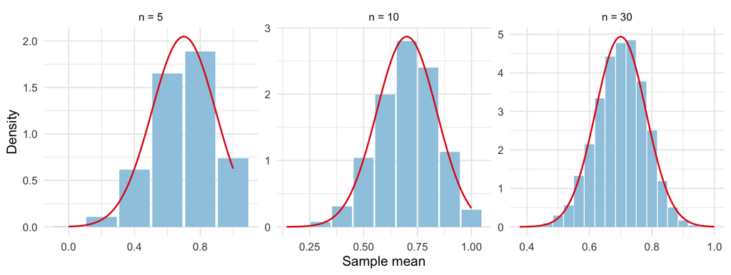

Sample means of non-identical Bernoulli trials, with one bar per possible average. The red curve is the normal approximation.

At sample size 5 the bars are far apart. At sample size 10 they follow the curve more closely and are still separate: the possible means are multiples of one over that sample size. At sample size 30 the steps are $1/30$. Each panel has its own horizontal scale, so this picture is about shape. The next figure uses one scale, from 0 to 1, so the change in width is visible. A mean of zeros and ones cannot fall outside that interval.

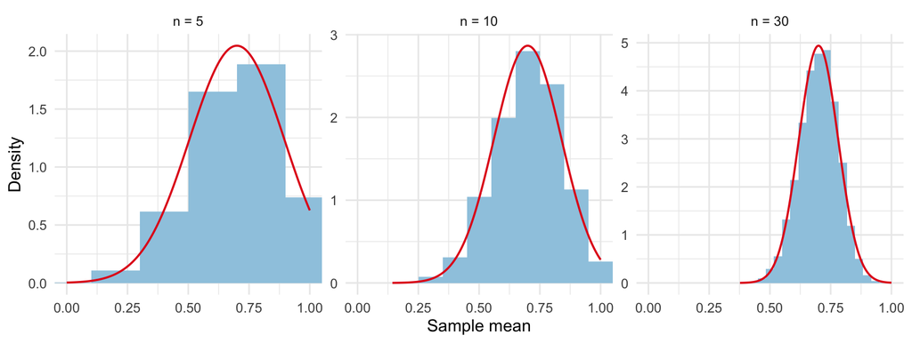

The same Bernoulli means on one horizontal scale, from 0 to 1. The averages pull in toward 0.70. A single observation stays 0 or 1.

On that shared scale, sample size 5 is spread out. Sample size 30 is a tight pile at 0.70. The center stays at 0.70. A single observation stays 0 or 1. The averages are what pull in.

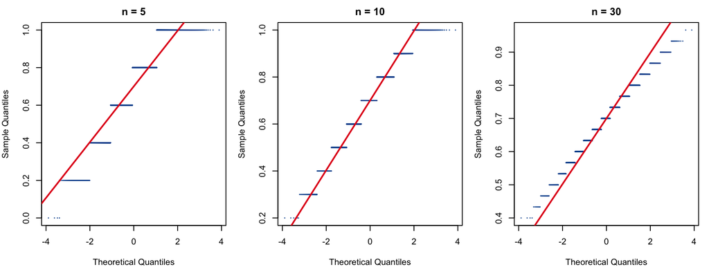

Q–Q plots of the Bernoulli means. The steps are the possible averages. The red line is qqline().

The Q–Q plot at sample size 5 is a staircase. The discrepancy there is 0.367. At sample size 10 it is 0.235, and at sample size 30 it is 0.277. A straight plot here means the mound is roughly bell-shaped. It does not mean the means stopped landing on a grid. The discrepancy is supporting evidence. It is not a separate cutoff, and it does not fall in a smooth line from row to row.

A Shapiro–Wilk test is a fifth check. The test accepts at most 5,000 values, so each row uses a random 5,000 of the 10,000 means. That subsample is drawn after the experiment, with the same student seed, so the table of means does not change.

```r
shapiro_results <- do.call(rbind, lapply(focus_n, function(n) {
  set.seed(student_id)
  fit <- shapiro.test(sample(stored_means[[as.character(n)]], 5000))
  data.frame(
    sample_size = n,
    W = unname(fit$statistic),
    p_value = fit$p.value
  )
}))
```

Shapiro–Wilk tests on 5,000 of the 10,000 Bernoulli means. The means sit on a grid, so this test is not the cutoff.

| Sample size | W | p-value |
| --- | --- | --- |
| 5 | 0.896 | <0.001 |
| 10 | 0.952 | <0.001 |
| 30 | 0.983 | <0.001 |

W moves toward 1, from 0.896 at sample size 5 to 0.983 at sample size 30. The p-values are <0.001, <0.001, and <0.001. The means are tied on multiples of $1/n$, and Shapiro–Wilk assumes a continuous distribution, so a small p-value here is partly that discreteness. The rule in this file stays the skewness, the excess kurtosis, and the standard-error check.

## Conclusion

The formula first drops under 0.25 in absolute value at sample size 10. The first Yes on this seed is sample size 10. On this table that first Yes is also the smallest size that keeps passing, because every larger tested row passes.

The smallest size after which every larger row in this table passes is 10. At that size the skewness is -0.231, the theoretical skewness is -0.239, the excess kurtosis is -0.161, and the standard-error ratio is 1.003. The margin on the skewness is thin. Sample size 30 also passes: skewness -0.169, theoretical skewness -0.141.

Thirty is enough for these trials. It is not what makes the width correct. The standard-error ratio is already 0.987 at sample size 5. Thirty is also not a rule for every population. The exponential in this project still fails at 30, because every observation there has the same strong skew. Different probabilities, by themselves, did not push this answer past 30.

I will not call the sample-size-30 picture a continuous normal curve. The averages sit on multiples of $1/30$. The bars are still a grid.

The observations did not become identical. The success probability still decreases from 0.90 to 0.50. The sampling distribution changed because each mean mixes more of those trials, no single trial dominates the sum, and the pile of averages moves toward a bell and gets narrower. That is the part of the Central Limit Theorem that survives after the identical-distribution assumption is dropped. The only seed in this file is the student ID, 1069.

**For these non-identical trials, the sample mean becomes approximately normal at about (n=10), and (n=30) is more than enough. Even though the success probabilities are different, averaging enough trials still produces a roughly bell-shaped distribution.**

## What surprised me

The standard error and the shape do not become acceptable together. At sample size 5 the standard-error ratio is 0.987 and the skewness is still -0.314. Getting the spread right is a check that the variance formula is the right one. It is not evidence that the histogram is a normal curve.

The other surprise is how little the broken assumption cost. The observations are not identically distributed, and the smallest size that holds is still 10. I checked every integer from 8 through 18 because a skewness estimate from 10^{4} means wobbles by about 0.024. On this seed the Yes column stays Yes after sample size 10. That is a statement about this table. It is not a promise that every larger sample size would pass.